# Section 2: Missing Data and Imputation

2026-06-08

# 1 Introduction

One of the most common problems in real data analysis is missing data: observations where one or more variable values were not recorded. In R, missing values are represented as `NA` (*Not Available*). Before fitting any model, it is essential to understand *why* data are missing and *how much* is missing, because the choice of how to handle it can substantially affect results.

We will use the `airquality` dataset, available in the base R installation. It contains daily air quality measurements in New York from May to September 1973, with 153 observations and 6 variables: `Ozone`, `Solar.R`, `Wind`, `Temp`, `Month`, and `Day`.

```r
data(airquality)
str(airquality)
```

```
## 'data.frame':    153 obs. of  6 variables:
##  $ Ozone  : int  41 36 12 18 NA 28 23 19 8 NA ...
##  $ Solar.R: int  190 118 149 313 NA NA 299 99 19 194 ...
##  $ Wind   : num  7.4 8 12.6 11.5 14.3 14.9 8.6 13.8 20.1 8.6 ...
##  $ Temp   : int  67 72 74 62 56 66 65 59 61 69 ...
##  $ Month  : int  5 5 5 5 5 5 5 5 5 5 ...
##  $ Day    : int  1 2 3 4 5 6 7 8 9 10 ...
```

```r
# Number and percentage of NAs per variable
na_counts <- colSums(is.na(airquality))
na_pct    <- round(100 * na_counts / nrow(airquality), 1)
data.frame(Missing = na_counts, Percent = na_pct)
```

|  | Missing | Percent |
| --- | --- | --- |
| Ozone | 37 | 24.2 |
| Solar.R | 7 | 4.6 |
| Wind | 0 | 0.0 |
| Temp | 0 | 0.0 |
| Month | 0 | 0.0 |
| Day | 0 | 0.0 |

# 2 Types of Missing Data

Understanding *why* data are missing matters because it determines which imputation methods are valid. The standard taxonomy, due to Rubin (1976), has three categories.

## 2.1 Missing Completely at Random (MCAR)

The probability of a value being missing is unrelated to any variable in the dataset — observed or unobserved. In other words, the missingness is pure chance: the data that are missing look just like the data that are observed.

*Example*: a sensor randomly fails on some days regardless of the weather.

Under MCAR, complete-case analysis (removing missing rows) is unbiased, though it reduces sample size. MCAR is the most convenient assumption but also the hardest to justify in practice.

**How to check**: compare the distribution of observed variables between cases with and without missing data. Under MCAR, they should look similar. *Little’s MCAR test* (available in the `naniar` package) provides a formal test.

## 2.2 Missing at Random (MAR)

The probability of a value being missing depends on *other observed variables*, but not on the missing value itself once those are accounted for.

*Example*: ozone readings are more likely to be missing on hot days (high `Temp`), but given the temperature, the probability of missingness is unrelated to the actual ozone level.

MAR is the most common working assumption in practice. Under MAR, methods such as multiple imputation and maximum likelihood estimation are valid.

## 2.3 Missing Not at Random (MNAR)

The probability of a value being missing depends on the value itself, even after conditioning on other observed variables.

*Example*: very high ozone values may not be recorded because the instrument saturates and fails to log a reading.

MNAR is the most problematic case: no standard imputation method fully corrects for it. Handling MNAR requires explicit modelling of the missingness mechanism, which is beyond the scope of this course.

## 2.4 Summary of Types

| Type | Missingness depends on… | Complete-case analysis | Standard imputation |
| --- | --- | --- | --- |
| MCAR | Nothing | Unbiased | Valid |
| MAR | Other observed variables | Biased | Valid |
| MNAR | The missing value itself | Biased | Biased |

# 3 Visualising Missing Data

Before imputing, always visualise the missing data pattern. This helps assess how much is missing and whether there is any structure to the missingness.

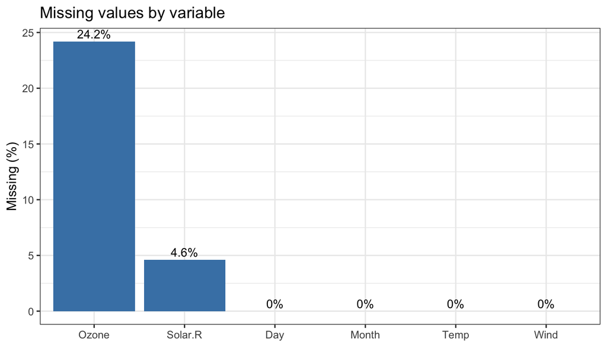

Figure 3.1: Percentage of missing values per variable in the airquality dataset.

```r
df_na <- data.frame(
  variable = names(na_pct),
  percent  = as.numeric(na_pct)
)

ggplot(df_na, aes(x = reorder(variable, -percent), y = percent)) +
  geom_col(fill = "steelblue") +
  geom_text(aes(label = paste0(percent, "%")), vjust = -0.4, size = 3.5) +
  labs(title = "Missing values by variable",
       x = NULL, y = "Missing (%)") +
  theme_bw()
```

A useful complementary plot is a **missingness map**: each row is an observation, each column a variable, and cells are coloured by whether the value is present or missing. This reveals whether missing values cluster in time or co-occur across variables.

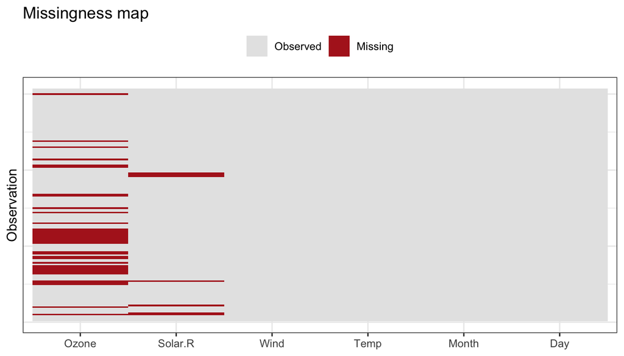

Figure 3.2: Missingness map for the airquality dataset. Dark cells indicate missing values.

```r
# Build a long data frame of missingness indicators
df_map <- reshape2::melt(is.na(airquality))
names(df_map) <- c("observation", "variable", "missing")

ggplot(df_map, aes(x = variable, y = observation, fill = missing)) +
  geom_tile() +
  scale_fill_manual(values = c("FALSE" = "grey90", "TRUE" = "firebrick"),
                    labels = c("Observed", "Missing")) +
  labs(title = "Missingness map", x = NULL, y = "Observation", fill = NULL) +
  theme_bw() +
  theme(legend.position = "top",
        axis.text.y = element_blank(),
        axis.ticks.y = element_blank())
```

From Figure 3.2 we can see that `Ozone` and `Solar.R` missing values do not appear to cluster at the same observations, suggesting their missingness mechanisms may be independent.

# 4 Imputation Methods

We now discuss the main imputation approaches, roughly in order of increasing sophistication.

## 4.1 Complete Case Analysis (Deletion)

The simplest approach: remove any observation that has at least one missing value. In R, `na.omit()` or `complete.cases()` do this.

```r
aq_complete <- na.omit(airquality)
cat("Original rows:", nrow(airquality), "\n")
```

```
## Original rows: 153
```

```r
cat("After deletion:", nrow(aq_complete), "\n")
```

```
## After deletion: 111
```

```r
cat("Rows removed:", nrow(airquality) - nrow(aq_complete), "\n")
```

```
## Rows removed: 42
```

We lose 42 observations (27.5% of the data).

**When to use**: only when data are MCAR and the fraction missing is small. Otherwise, deletion introduces bias and reduces power.

**When not to use**: if data are MAR or MNAR, or if the proportion missing is non-trivial (a common rule of thumb is more than 5%).

## 4.2 Last Observation Carried Forward (LOCF)

LOCF replaces each missing value with the most recent preceding non-missing value in the same variable. It is most natural for time-ordered data.

```r
locf <- function(x) {
  # carry forward the last non-NA value
  for (i in seq_along(x)) {
    if (is.na(x[i]) && i > 1) x[i] <- x[i - 1]
  }
  x
}

aq_locf          <- airquality
aq_locf$Ozone    <- locf(aq_locf$Ozone)
aq_locf$Solar.R  <- locf(aq_locf$Solar.R)

cat("Remaining NAs after LOCF - Ozone:", sum(is.na(aq_locf$Ozone)),
    " Solar.R:", sum(is.na(aq_locf$Solar.R)), "\n")
```

```
## Remaining NAs after LOCF - Ozone: 0  Solar.R: 0
```

Note that LOCF cannot fill missing values that appear at the very start of the series (no previous value to carry forward). In the `airquality` data, the first observation of `Ozone` is not missing, so no leading NAs arise here.

**Limitation**: LOCF artificially flatlines the series at missing stretches and ignores the natural variability of the variable. It tends to underestimate variance and can introduce bias if the variable is trending.

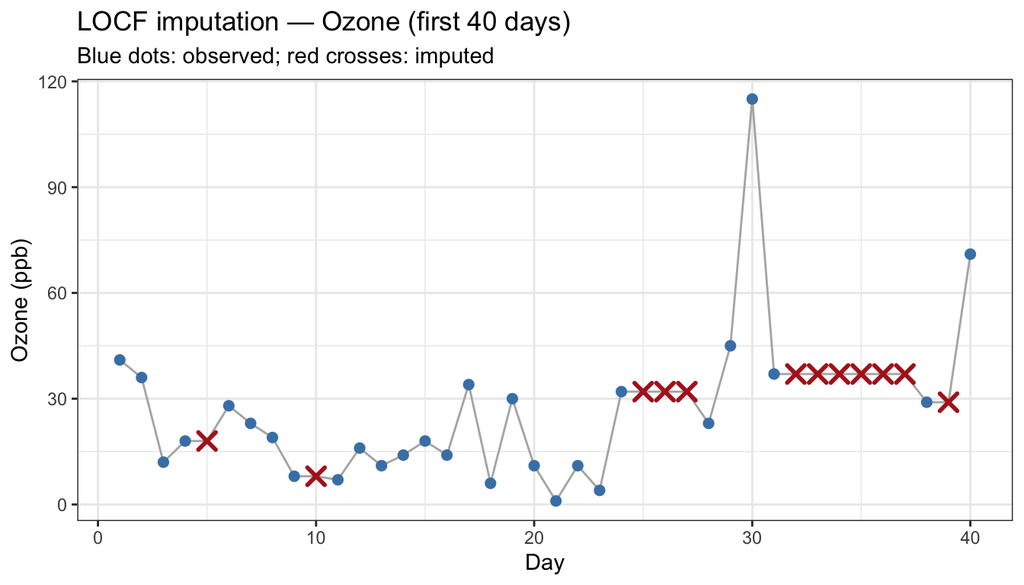

Figure 4.1: Original Ozone values (points) and LOCF-imputed values (crosses) for the first 40 observations.

```r
df_orig <- data.frame(day = 1:40, ozone = airquality$Ozone[1:40], type = "Observed")
df_locf <- data.frame(day = 1:40, ozone = aq_locf$Ozone[1:40],   type = "LOCF")

# Mark imputed points
imputed_idx <- which(is.na(airquality$Ozone[1:40]))

ggplot() +
  geom_line(data = df_locf, aes(x = day, y = ozone), colour = "grey70") +
  geom_point(data = df_orig, aes(x = day, y = ozone),
             colour = "steelblue", size = 2) +
  geom_point(data = df_locf[imputed_idx, ], aes(x = day, y = ozone),
             shape = 4, colour = "firebrick", size = 3, stroke = 1.5) +
  labs(title = "LOCF imputation — Ozone (first 40 days)",
       subtitle = "Blue dots: observed; red crosses: imputed",
       x = "Day", y = "Ozone (ppb)") +
  theme_bw()
```

## 4.3 Mean and Mode Imputation

Replace each missing value with the mean (for continuous variables) or the mode (for categorical variables) of the observed values of that variable.

```r
aq_mean         <- airquality
ozone_mean      <- mean(aq_mean$Ozone,   na.rm = TRUE)
solar_mean      <- mean(aq_mean$Solar.R, na.rm = TRUE)

aq_mean$Ozone[is.na(aq_mean$Ozone)]     <- ozone_mean
aq_mean$Solar.R[is.na(aq_mean$Solar.R)] <- solar_mean

cat(sprintf("Ozone mean used for imputation:   %.2f\n", ozone_mean))
```

```
## Ozone mean used for imputation:   42.13
```

```r
cat(sprintf("Solar.R mean used for imputation: %.2f\n", solar_mean))
```

```
## Solar.R mean used for imputation: 185.93
```

**Limitation**: mean imputation preserves the mean of the variable but distorts its distribution — it compresses the variance and can distort correlations with other variables. The imputed values are all identical, which is unrealistic.

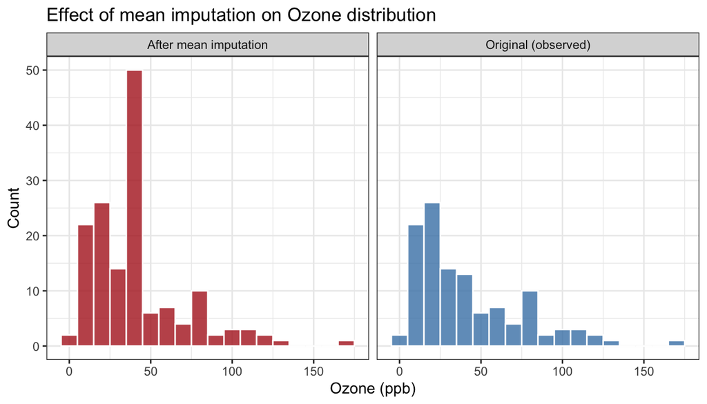

```r
df_dist <- rbind(
  data.frame(ozone = airquality$Ozone[!is.na(airquality$Ozone)], type = "Original (observed)"),
  data.frame(ozone = aq_mean$Ozone, type = "After mean imputation")
)

ggplot(df_dist, aes(x = ozone, fill = type)) +
  geom_histogram(binwidth = 10, colour = "white", alpha = 0.8) +
  facet_wrap(~ type) +
  scale_fill_manual(values = c("Original (observed)" = "steelblue",
                               "After mean imputation" = "firebrick")) +
  labs(title = "Effect of mean imputation on Ozone distribution",
       x = "Ozone (ppb)", y = "Count") +
  theme_bw() +
  theme(legend.position = "none")
```

Figure 4.2 clearly shows the artificial spike at the mean value after imputation.

## 4.4 Regression Imputation

A more principled approach: fit a regression model using the complete observations, then use the model to predict the missing values. This preserves the relationship between variables better than mean imputation.

Here we predict `Ozone` from `Temp` and `Wind`, and `Solar.R` from `Temp`.

```r
# Fit models on complete cases only
fit_ozone  <- lm(Ozone   ~ Temp + Wind, data = airquality)
fit_solar  <- lm(Solar.R ~ Temp,        data = airquality)

aq_reg <- airquality

# Predict and fill missing Ozone values
missing_ozone           <- is.na(aq_reg$Ozone)
aq_reg$Ozone[missing_ozone] <-
  predict(fit_ozone, newdata = aq_reg[missing_ozone, ])

# Predict and fill missing Solar.R values
missing_solar               <- is.na(aq_reg$Solar.R)
aq_reg$Solar.R[missing_solar] <-
  predict(fit_solar, newdata = aq_reg[missing_solar, ])

cat("Remaining NAs - Ozone:", sum(is.na(aq_reg$Ozone)),
    " Solar.R:", sum(is.na(aq_reg$Solar.R)), "\n")
```

```
## Remaining NAs - Ozone: 0  Solar.R: 0
```

**Limitation**: regression imputation gives a single predicted value with no uncertainty — it underestimates the variance of the variable and overestimates the precision of subsequent analyses. *Stochastic* regression imputation (adding a random residual term to the prediction) partially addresses this.

## 4.5 Multiple Imputation with `mice`

The gold standard for missing data under MAR is **multiple imputation** (Rubin, 1987). Instead of replacing each missing value with a single estimate, multiple imputation generates $m$ complete datasets, each with slightly different imputed values drawn from the predictive distribution of the missing data. Each dataset is analysed separately, and the results are combined using *Rubin’s rules*.

The `mice` package (*Multivariate Imputation by Chained Equations*) implements this in R.

```r
library(mice)

set.seed(42)
# m = 5 imputed datasets, method = "pmm" (predictive mean matching, good for
# continuous variables)
imp <- mice(airquality, m = 5, method = "pmm", printFlag = FALSE)
summary(imp)
```

```
## Class: mids
## Number of multiple imputations:  5
## Imputation methods:
##   Ozone Solar.R    Wind    Temp   Month     Day
##   "pmm"   "pmm"      ""      ""      ""      ""
## PredictorMatrix:
##         Ozone Solar.R Wind Temp Month Day
## Ozone       0       1    1    1     1   1
## Solar.R     1       0    1    1     1   1
## Wind        1       1    0    1     1   1
## Temp        1       1    1    0     1   1
## Month       1       1    1    1     0   1
## Day         1       1    1    1     1   0
```

The imputed datasets can be extracted and analysed individually, then combined:

```r
# Fit the same regression on each imputed dataset and pool results
fit_mice <- with(imp, lm(Ozone ~ Solar.R + Wind + Temp))
pooled   <- pool(fit_mice)
summary(pooled)
```

| term | estimate | std.error | statistic | df | p.value |
| --- | --- | --- | --- | --- | --- |
| (Intercept) | -67.82028057 | 20.33231894 | -3.335590 | 102.2519 | 1.187061e-03 |
| Solar.R | 0.06101588 | 0.02035198 | 2.998032 | 129.4168 | 3.258981e-03 |
| Wind | -2.85189410 | 0.58317202 | -4.890314 | 102.9827 | 3.722528e-06 |
| Temp | 1.62423806 | 0.22301335 | 7.283143 | 114.2386 | 4.494016e-11 |

**Why multiple imputation is better**: it properly accounts for the uncertainty in the imputed values. Single imputation methods (mean, regression) treat imputed values as if they were observed, leading to standard errors that are too small and p-values that are too significant.

**When to use `mice`**: when data are MAR, the proportion of missing data is non-trivial, and the downstream analysis requires valid uncertainty quantification.

# 5 Comparing the Methods

To illustrate the impact of imputation choice, we fit a simple linear regression `Ozone ~ Solar.R` on each imputed dataset and compare the $R^2$ values.

```r
# Helper: R^2 from a fitted lm
r2 <- function(fit) summary(fit)$r.squared

fit_orig     <- lm(Ozone ~ Solar.R, data = na.omit(airquality))
fit_del      <- lm(Ozone ~ Solar.R, data = aq_complete)
fit_locf_lm  <- lm(Ozone ~ Solar.R, data = aq_locf)
fit_mean_lm  <- lm(Ozone ~ Solar.R, data = aq_mean)
fit_reg_lm   <- lm(Ozone ~ Solar.R, data = aq_reg)

# For mice, pool R^2 across imputed datasets using mean
mice_r2 <- mean(sapply(1:5, function(i)
  r2(lm(Ozone ~ Solar.R, data = complete(imp, i)))))

df_r2 <- data.frame(
  Method = c("Complete cases", "Deletion", "LOCF",
             "Mean imputation", "Regression imputation", "mice (mean)"),
  R2 = round(c(r2(fit_orig), r2(fit_del), r2(fit_locf_lm),
               r2(fit_mean_lm), r2(fit_reg_lm), mice_r2), 3)
)
df_r2
```

| Method | R2 |
| --- | --- |
| Complete cases | 0.121 |
| Deletion | 0.121 |
| LOCF | 0.056 |
| Mean imputation | 0.092 |
| Regression imputation | 0.094 |
| mice (mean) | 0.105 |

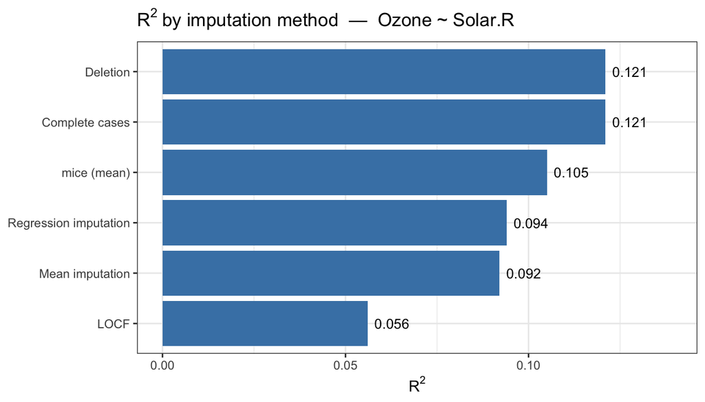

Figure 5.1: R-squared for the regression Ozone ~ Solar.R under each imputation method.

```r
ggplot(df_r2, aes(x = reorder(Method, R2), y = R2)) +
  geom_col(fill = "steelblue") +
  geom_text(aes(label = R2), hjust = -0.2, size = 3.5) +
  coord_flip() +
  ylim(0, max(df_r2$R2) * 1.15) +
  labs(title = expression(R^2 ~ "by imputation method  —  Ozone ~ Solar.R"),
       x = NULL, y = expression(R^2)) +
  theme_bw()
```

Note that the effect of mean imputation on $R^2$ depends on which variable is imputed. When the *response* is imputed with its mean, those observations add noise to the regression (the imputed $Y$ is constant regardless of $X$), which typically *reduces* $R^2$. When a *predictor* is imputed with its mean, the imputed observations cluster at $\bar{X}$ and their effect on $R^2$ depends on the correlation structure. In either case, mean imputation distorts the distribution and biases downstream analyses.

# 6 Practical Guidelines

Some practical advice before choosing an imputation method:

1. **Always visualise** the missing data pattern before doing anything else.
2. **Assess the mechanism**: is missingness related to other observed variables? If so, MAR is more plausible than MCAR.
3. **Consider the proportion**: if less than 5% of data are missing and MCAR is plausible, complete-case analysis is often acceptable.
4. **Avoid mean imputation** when the proportion missing is large or downstream analyses require accurate standard errors.
5. **Prefer `mice`** for MAR data when valid inference is important.
6. **Never impute the response variable** $Y$ in a supervised learning context — imputing $Y$ is circular reasoning.

# 7 Summary

| Method | Preserves mean | Preserves variance | Preserves correlations | Valid under |
| --- | --- | --- | --- | --- |
| Deletion | Yes | Yes | Yes | MCAR only |
| LOCF | Approx. | No | No | Time series, MCAR |
| Mean imputation | Yes | No | No | MCAR, small % missing |
| Regression imputation | Yes | Partial | Yes | MAR |
| Multiple imputation (`mice`) | Yes | Yes | Yes | MAR |

# 8 References

- Rubin, D. B. (1976). Inference and missing data. *Biometrika*, 63(3), 581–592.
- Rubin, D. B. (1987). *Multiple Imputation for Nonresponse in Surveys*. Wiley.
- van Buuren, S. (2018). *Flexible Imputation of Missing Data* (2nd ed.). CRC Press. Freely available online at https://stefvanbuuren.name/fimd.
- van Buuren, S. & Groothuis-Oudshoorn, K. (2011). mice: Multivariate imputation by chained equations in R. *Journal of Statistical Software*, 45(3), 1–67.
- James, G., Witten, D., Hastie, T., & Tibshirani, R. (2023). *An Introduction to Statistical Learning with Applications in R* (2nd ed.). Springer.